# Heterogeneous Agent Models

## Economic Modelling and Forecasting

### Centre for Central Bank Studies

Jamie Lenney · October 2026

Code/slides: https://github.com/s0840389/TSP_HA

## Objectives

- Motivate incomplete markets
- Understand how income risk and borrowing constraints underpin HA model mechanisms
- Know how to solve a HA model
- Examine the properties of a Huggett model

**Further reading**

- Ljungqvist and Sargent, *Recursive Macroeconomic Theory*, chapters 17–18
- Auclert, A., Bardóczy, B., Rognlie, M., & Straub, L. (2021). Using the sequence‐space Jacobian to solve and estimate heterogeneous‐agent models. Econometrica, 89(5), 2375-2408.
- Sequence-space Jacobian toolkit: https://github.com/shade-econ/sequence-jacobian

## Incomplete Markets

What is this?

- Can think of a representative agent model as a model where individuals have written contracts to hedge against all risk
  - They are still exposed to aggregate risk
  - Can still have complete markets models with wealth distribution but all agents' consumption would move proportionally in the same way.
- When this is not possible we have incomplete markets
  - e.g. There are not sufficient assets/contracts to trade.
- Incomplete markets creates incentives for self-insurance
  - Saving for a 'rainy day'

## Consumption Savings Problem

Households maximise lifetime expected utility:

$$\max_{\{c_t\}_{t=0}^{\infty}} \mathbb{E}_0 \sum_{t=0}^{\infty} \beta^t u(c_t)$$

where:

- $c_t$ = consumption at time $t$
- $\beta \in (0,1)$ = discount factor
- $u(c)$ = instantaneous utility function (typically CRRA $\frac{c^{1-\sigma}}{1-\sigma}$)

## Utility function properties

1. **Strictly increasing**: $u'(c) > 0$
   - More consumption is always preferred
2. **Strictly concave**: $u''(c) < 0$
   - Diminishing marginal utility
   - Induces consumption smoothing
3. **Positive third derivative: Prudence**: $u'''(c) > 0$
   - **Prudence** means the marginal utility function is convex.
   - **Key implication**: Creates a **precautionary savings motive**
     - When facing income risk, agents save more as insurance against bad shocks
     - Expected marginal utility exceeds marginal utility of expected consumption: $\mathbb{E}[u'(c')] > u'(\mathbb{E}[c'])$ (Jensen's inequality)
4. **Inada conditions**:
   - $\lim_{c \to 0} u'(c) = \infty$ ensures $c > 0$ always
   - $\lim_{c \to \infty} u'(c) = 0$ ensures interior solutions

## Prudence and Precautionary Savings

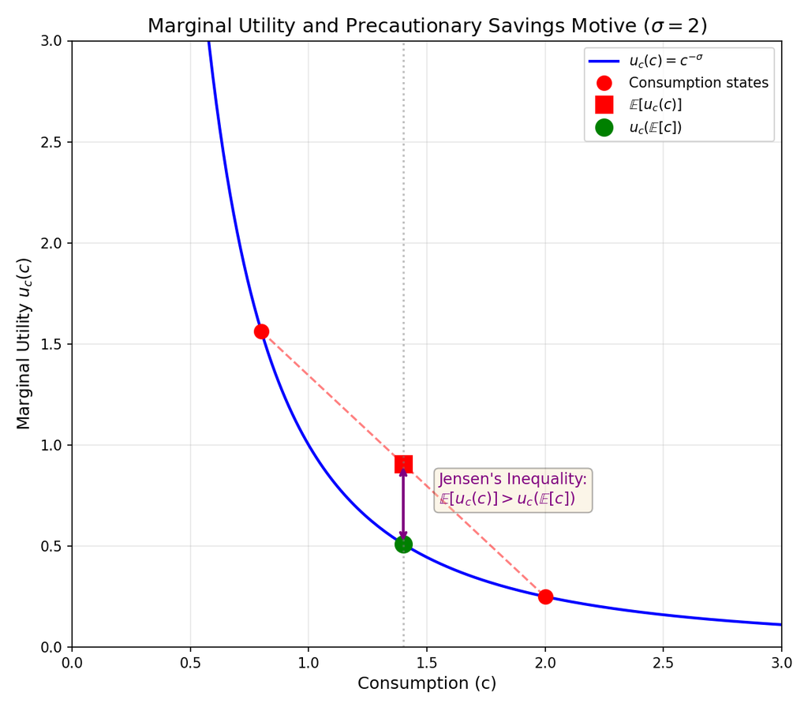

## Constraints

#### Budget Constraint

$$c_t + a_{t+1} = (1+r_t)a_t + \underbrace{z_t w_t}_{y_t}$$

- $a_t$ = assets at beginning of period $t$
- $r_t$ = interest rate
- $w_t z_t$ = labor income (stochastic)

#### Borrowing Constraint

$$a_{t+1} \geq \underline{a}$$

- $\underline{a}$ = borrowing limit
- Common cases: $\underline{a} = 0$ (no borrowing) or $\underline{a} < 0$ (some debt allowed)

### Natural borrowing constraint

In the worst-case scenario, households must still be able to afford the interest payments on their debt

$$\underline{a}=-\frac{w_{low}z_{low}}{r_{high}}$$

### Income Process

#### Stochastic Income

Labor productivity (income) follows a Markov process:

$$\log z_t = \rho \log z_{t-1} + \epsilon_t, \quad \epsilon_t \sim N(0, \sigma_\epsilon^2)$$

Can be discretized into:

- $z_t \in \{z_1, z_2, ..., z_N\}$ (finite states)
- Transition matrix $\Pi$ where $\Pi_{ij} = \Pr(z_{t+1} = z_j | z_t = z_i)$

**Key feature**: Households face **uninsurable idiosyncratic risk**

- Cannot fully smooth consumption
- Need to self-insure through savings

### Bellman Equation

#### Recursive Formulation

$$V(a, y) = \max_{a' \geq \underline{a}} \left\{ u(c) + \beta \mathbb{E}[V(a', y') | y] \right\}$$

subject to: $$c = (1+r)a + y - a'$$

where:

- $V(a,y)$ = value of having assets $a$ and income $y$ today
- $a'$ = assets tomorrow (choice variable)
- $\mathbb{E}[V(a', y') | y] = \sum_{y'} \Pi(y'|y) V(a', y')$
- **State variables**: $(a, y)$
- **Choice variable**: $a'$ (equivalently $c$)

### First Order Conditions

#### Lagrangian

$$\mathcal{L} = u(c) + \beta \mathbb{E}[V(a',y')\,|\,y] + \lambda(a' - \underline{a})$$

Derivative of $\mathcal{L}$ w.r.t. $a'$

$$0 = -u_c(c) +\beta \mathbb{E}[V_a(a',y')] +\lambda $$

Derivative of $V(a,y)$ w.r.t. $a$ (envelope condition)

$$ V_a(a,y) = \beta (1+r)\mathbb{E}[V_a(a',y')]+(1+r)\lambda$$

Putting these together we have

$$ V_a(a,y) = (1+r)u_c(c)$$

And our Euler equation

$$ u_c(c) = \beta \mathbb{E}[(1+r')u_c(c')]+\lambda$$

### Complementary Slackness

1. $\lambda \geq 0$
2. $a' - \underline{a} \geq 0$
3. $\lambda (a' - \underline{a}) = 0$
- Binding constraint ($\lambda>0$)
  - $ u_c(c) = \beta \mathbb{E}[(1+r')u_c(c')]+\lambda > \beta \mathbb{E}[(1+r')u_c(c')]$
  - implies consumption is below what agent would want
- Otherwise
  - $ u_c(c) = \beta \mathbb{E}[(1+r')u_c(c')]$

## Value Function Iteration (VFI)

- Goal: solve household problem by iterating on the Bellman equation directly to find the value function and policy functions.
- Core idea
  - For each state (productivity z, assets a), maximize over all possible asset choices a' to find the value function.
  - Bellman equation:

  $$V^{j}(z,a) = \max_{a'} \left\{ u(c) + \beta\, \mathbb{E}[V^{j-1}(z',a') \,|\, z] \right\}$$
  - Find best choice, update value function and continue until it converges $\lVert V^{j}-V^{j-1}\rVert \leq \epsilon$

## Value Function Iteration (VFI)

- Algorithm (one backward step)
  1. For each $(z, a)$ state, construct the value $V(z,a,a')$ for each possible a' choice on grid
  2. Calculate value: $V = u(c) + \beta\, \mathbb{E}[V_{t+1}(z', a')]$
  3. Find optimal choice: $a^* = \arg\max_{a'} V$
  4. Store $V(z,a) = \max_{a'} V$ and policy $a'(z,a) = a^*$

## Value Function Iteration (VFI)

- Advantages
  - Simple and robust
  - No need for invertible Euler equation
  - Can handle non-convexities, occasionally binding constraints
- Limitations / notes
  - Computationally expensive: $O(n_Z \times n_A^2)$ per iteration
  - Policy functions can be jagged/non-smooth with coarse grids
  - Requires fine grids (nA = 2000+) for smooth policies
  - Much slower than other methods (e.g. EGM) for standard models

```python
cali={} # calibration

# household
cali['beta']=0.98 # patience
cali['sigma']=2 # risk aversion
cali['eis']=1/cali['sigma'] # intertemporal elasticity of substitution
cali['bc']=-0.2
cali['borwedge']=0.0

cali['rho_z']=0.97
cali['sd_z']=0.6

# aggregate economy
cali['r']=0.04/4
cali['w']=1.0
cali['govT']=0

# discretization
cali['nA']=2000
cali['nZ']=5
cali['amax']=125
```

```python
## Household problem

def make_grid(bc, amax, nA,nZ,rho_z,sd_z):

    z_grid, pi_z, Pi = grids.markov_rouwenhorst(rho=rho_z, sigma=sd_z, N=nZ)
    a_grid = utilities.discretize.nonlinspace(amax,nA ,1.2, amin = bc) # normalized grid between zero and one with n_a number of points

    return z_grid, pi_z, Pi, a_grid


def income(w,r,borwedge,a_grid,z_grid,govT):

    rexpand=r*np.ones_like(a_grid)
    rexpand[a_grid<0]=r+borwedge
    coh = (1+rexpand)*a_grid + w*z_grid[:, np.newaxis]+govT

    return coh


def household_init( r, coh, eis): # initial guess for marginal value function
    Va = (1 + r) * (0.1 * coh) ** (-1 / eis)
    return Va
```

```python
def household_vfit_init( r, coh, eis): # initial guess for value function
    V = (0.1 * coh)**(1-1/eis)/(1-1/eis)  # utility level
    return V

@het(exogenous='Pi', policy='a', backward='V', backward_init=household_vfit_init)
def household_vfit(V_p, a_grid, r, coh, beta, eis,nZ):
    """Single backward iteration step using value function iteration (grid search) for households with CRRA utility.

    V_p    : array (nZ, nA), expected value function next period, E[V(z',a') | z]
    a_grid : array (nA), asset grid
    coh    : array (nZ, nA), cash on hand (1+r)a + wz + T
    beta, eis : discount factor, elasticity of intertemporal substitution

    Returns V (value function), a (asset policy a'), c (consumption policy), each (nZ, nA)
    """

    c=coh[:,:,np.newaxis]-a_grid[np.newaxis,np.newaxis,:]
    Vupdate=c**(1-1/eis)/(1-1/eis)+beta*V_p[:,np.newaxis,:]
    Vupdate[c<=0]=-1e10
    v_choice = np.argmax(Vupdate, axis=2)

    V = np.take_along_axis(Vupdate, v_choice[:, :, np.newaxis], axis=2).squeeze(axis=2)
    a = a_grid[v_choice]
    c = coh - a

    return V,a,c
```

```python
hh_vfit=household_vfit.add_hetinputs([make_grid,income])

cali_vfit=copy.deepcopy(cali)
ss0_vfit=hh_vfit.steady_state(cali_vfit)

c_vfit=ss0_vfit.internals['household_vfit']['c']
D_vfit=ss0_vfit.internals['household_vfit']['D']
a_grid_vfit=ss0_vfit.internals['household_vfit']['a_grid']
```

### Consumption Functions

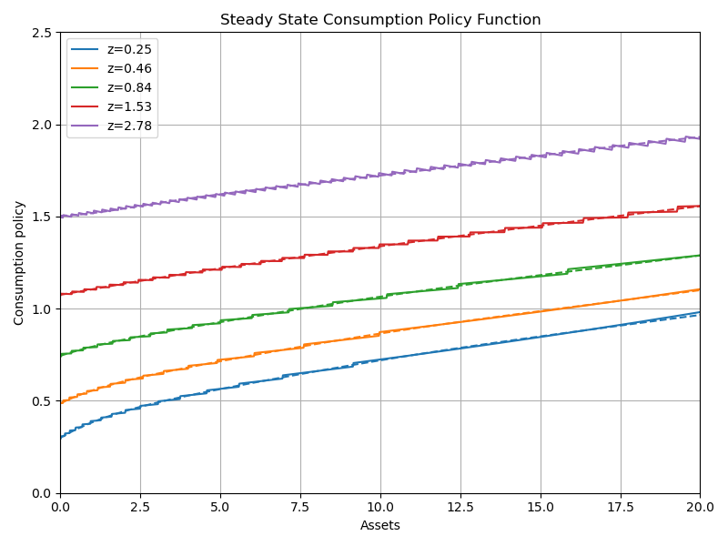

- Solid: VFI policy on the grid. Dashed: degree-15 polynomial fit

## Endogenous Gridpoint Method (EGM)

- Goal: solve household Euler equation without repeated root-finding at every asset grid point — faster and smoother than brute-force VFI.
- Core idea
  - Use Euler equation to compute optimal consumption on the *next-period* grid of assets (endogenous grid), then recover the implied current assets.
  - For CRRA utility: $u_c(c) = c^{-\sigma}$.
  - Euler gives $u_c(c_t) = \beta(1+r)\, \mathbb{E}[u_c(c_{t+1})]$ ⇒ $c_t = \left(\beta(1+r)\, \mathbb{E}[u_c(c_{t+1})]\right)^{-\frac{1}{\sigma}}$

## Endogenous Gridpoint Method (EGM)

- Algorithm (one backward step)
  1. For each $(z,a')$ compute expected marginal utility next period: $m = \beta\, \mathbb{E}[(1+r') u_c(c(z',a'))]$
     - $m(z,a')= \beta \sum_{z'} \Pi(z'|z)(1+r')u_c(c(z',a'))$
  2. Invert marginal utility to get consumption at each next-period asset grid point: $\tilde{c}(z,a') = m^{-\frac{1}{\sigma}}$
  3. Compute implied current assets: $a = \frac{ a'+\tilde{c}-y}{1+r}$
     - if I choose $a'$ with income state $z$, I must have had $a$ today
  4. Interpolate the policy from the endogenous grid $a$ back onto the exogenous asset grid
  5. Enforce borrowing constraint: where implied $a' < \underline{a}$, set $a' = \underline{a}$ and recompute $c = (1+r)a +y - a'$

## Endogenous Gridpoint Method (EGM)

- Advantages
  - No inner-loop maximization; vectorizable and much faster.
  - Produces smooth consumption/savings policies when monotonicity holds.
- Limitations / notes
  - Requires invertible Euler equation (works easily with CRRA).

```python
@het(exogenous='Pi', policy='a', backward='Va', backward_init=household_init)
def household(Va_p, a_grid, r, coh, beta, eis,nZ):
    """Single backward iteration step using the endogenous gridpoint method for households with CRRA utility.

    Va_p   : array (nZ, nA), expected marginal value of assets next period, E[V_a(z',a') | z]
    a_grid : array (nA), asset grid
    coh    : array (nZ, nA), cash on hand (1+r)a + wz + T
    r, beta, eis : interest rate, discount factor, elasticity of intertemporal substitution

    Returns Va (marginal value today), a (asset policy a'), c (consumption policy), each (nZ, nA)
    """

    uc_nextgrid= beta * Va_p

    c_today = uc_nextgrid ** (-(eis))

    a = interpolate.interpolate_y(c_today + a_grid, coh, a_grid) # when I have coh(t)=c_today(t) + a_grid(t+1) I chose a_grid; what do I choose on the coh grid today?
    misc.setmin(a, a_grid[0]) # apply borrowing constraint
    c = coh - a # work out consumption policy today on the a_grid
    Va = (1 + r) * c ** (-1 / (eis)) #calculate marginal value today on the a_grid

    return Va, a, c
```

### Consumption Function (EGM)

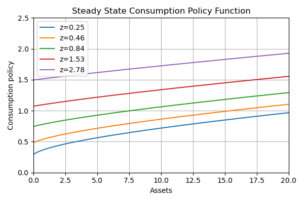

## Saving Rate by Assets and Income

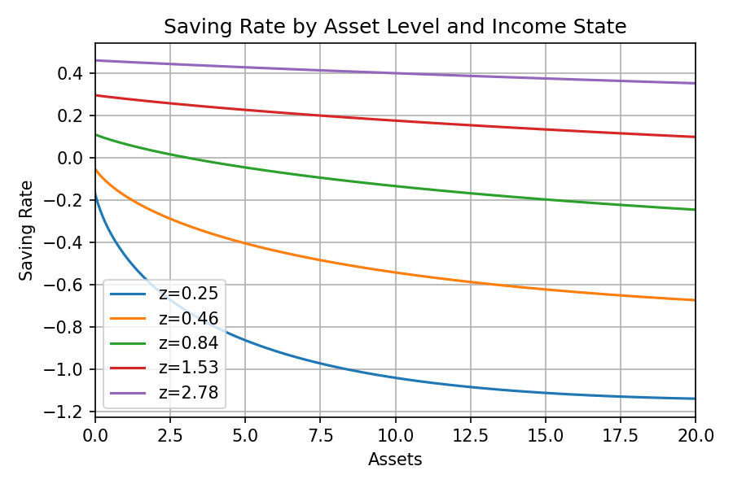

## Forward Iteration: Computing the Distribution

**Given policy functions**, we need to find the stationary distribution of households over $(z,a)$ states.

**Key objects:**

- Policy function: $a'(z,a)$ — optimal asset choice
- Transition matrix for income: $\Pi(z'|z)$ — probability of $z \to z'$
- Distribution: $D_t(z,a)$ — mass of households at state $(z,a)$ at time $t$

**Forward iteration equation:**

$$D_{t+1}(z',a') = \sum_{z,a} D_t(z,a) \cdot \mathbb{1}[a'(z,a) = a'] \cdot \Pi(z'|z)$$

**In words:** The mass at $(z',a')$ tomorrow equals the sum of all households who:

1. Choose $a'$ as their savings today
2. Transition from $z$ to $z'$ with probability $\Pi(z'|z)$

**Matrix representation:** We can write this as a **large transition matrix** $\Lambda$ where:

$$D_{t+1} = \Lambda D_t$$

where $D_t$ is vectorized over all $(z,a)$ states.

## Finding the Ergodic Distribution

**Steady state condition:** $D^* = \Lambda D^*$

This is an **eigenvalue problem** with eigenvalue = 1.

**Two approaches:**

1. **Power iteration** (iterate until convergence):
   - Start with initial guess $D_0$ (e.g., uniform distribution)
   - Iterate: $D_{t+1} = \Lambda D_t$
   - Continue until $\|D_{t+1} - D_t\| < \epsilon$
2. **Eigenvalue method** (fast and exact):
   - Find eigenvector of $\Lambda$ corresponding to eigenvalue = 1
   - $\Lambda v = 1 \cdot v$ where $v$ is the stationary distribution
   - Normalize: $D^* = v / \sum v$

## Steady-State Wealth Distribution

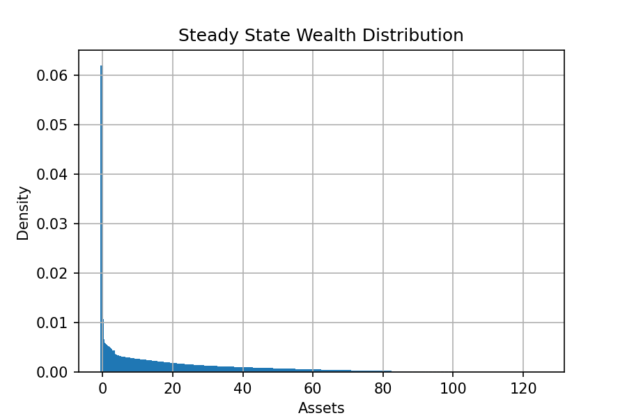

## Asset Demand and the Interest Rate

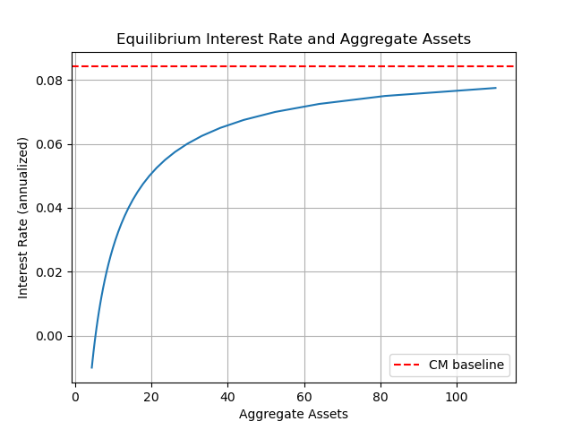

- Solving the model for different interest rates
- Aggregate asset demand increasing in the interest rate
- The more assets the more we move towards complete markets benchmark

## Borrowing Constraints and Asset Demand

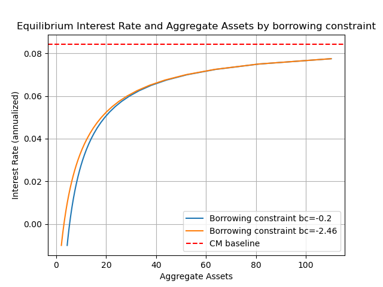

- Loosening the borrowing constraint shifts the asset demand curve to the left

## Aggregate Dynamics

- So far considered the model at its steady state
- Generally we want to think about aggregate dynamics
  - Theoretically under rational expectations this is basically impossible
  - But under some reasonable assumptions we have methods that make this feasible
- With HA models, now common to use perturbation methods around steady state to compute dynamic responses to shocks
  - e.g. SGU method (Bayer et al, 2024) or Sequence Space Jacobian (Auclert et al, 2021)
- All rely on taking derivatives around steady state and solving for policy functions that maintain the equilibrium conditions.

## TFP Shock in a Huggett model

$ Y_t=Z_t \int z_i di$

$A_t=B$

$\tau_t=r_tB$

$ \log{Z_t}=\rho \log{Z_{t-1}}+\epsilon_t$

- Fixed level of savings supported by fixed issuance of government bonds $B$.
- Output fluctuates with aggregate TFP Process
- Interest rate fluctuates to ensure savings supply equals demand
- Government pays for interest payment with a lump sum tax on all households
- Normalise such that $\int z_i di=1$

```python
@simple
def wage(Z):
    w=Z
    Y=Z
    return w,Y

@simple
def mkt_clearing(A,B,Y,C):
    asset_mkt=A-B
    goods_mkt=C-Y
    return asset_mkt, goods_mkt

@simple
def gov(r,B):
    govT=-r*B
    return govT
```

```python
cali_full=copy.deepcopy(cali)
cali_full['B']=8
cali_full['Z']=1

hugget_full = create_model([hh,wage,gov,mkt_clearing], name="Huggett")


unknowns_ss = {'r': 0.015}
targets_ss = {'asset_mkt': 0}

ss0_full = hugget_full.solve_steady_state(cali_full, unknowns_ss, targets_ss, solver="hybr")

print('r:',ss0_full['r'])
print('goods_mkt:',ss0_full['goods_mkt'])

# dynamics

Ghugget= hugget_full.solve_jacobian(ss0_full, ['r'], ['asset_mkt'], ['Z'], T=300)
```

```
r: 0.0038574596889343112
goods_mkt: 5.67532842943308e-09
```

## Response to a 1% TFP shock

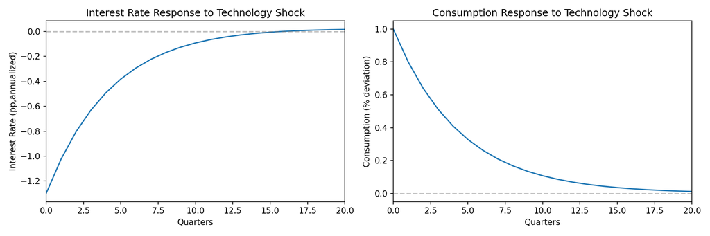

- Shock is temporary: today is better than tomorrow
- Households want to save more
- Interest rate has to fall to bring saving demand into equilibrium with supply ($r^*$ falls)

## Response to a 1% TFP news shock

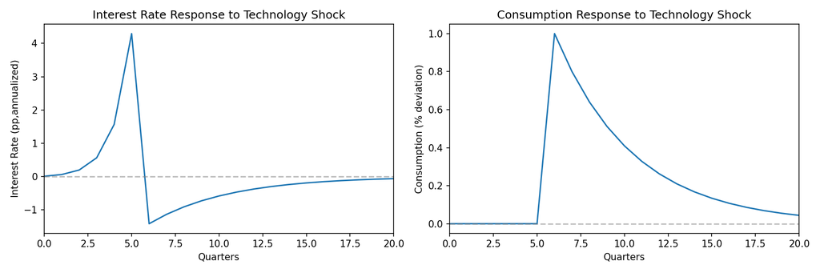

- Same shock, but anticipated 6 quarters in advance
- Tomorrow is now better than today
- Households want to save less (higher $r^*$)